# Perwalian Semester 1 Ganjil 2025/2026 | S2 Statistika Terapan FMIPA Unpad

**S2 Statistika Terapan FMIPA Unpad** Pasca Sarjana Statistika · Universitas Padjadjaran

master.statistics.unpad.ac.id

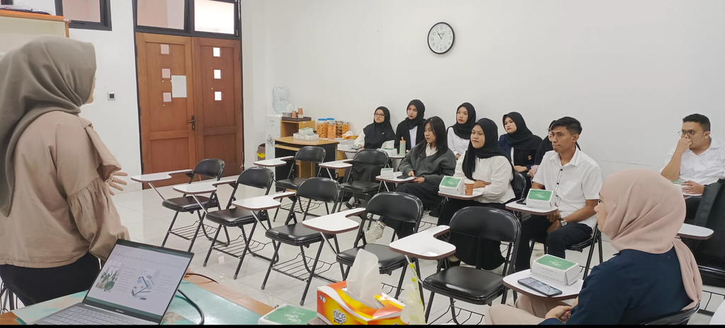

Berita Akademik · Perwalian Bersama

# Perwalian Semester 1 Ganjil 2025/2026

Penguatan pemahaman mahasiswa mengenai sistem perkuliahan, Kurikulum OBE 2025 minimum 54 SKS, visi–misi, tujuan program studi, capaian pembelajaran lulusan, serta kiat sukses menempuh pendidikan magister.

Senin, 11 Agustus 2025 08.00–10.00 WIB Gedung Statistika FMIPA Unpad Pelaksanaan luring

[figure not shown]

Semester**Semester 1 · Ganjil 2025/2026**

Waktu**11 Agustus 2025 · 08.00–10.00 WIB**

Tempat**Gedung Statistika FMIPA Unpad**

Kurikulum**OBE 2025 · Minimum 54 SKS**

## Memulai perjalanan akademik dengan arah yang jelas

Program Studi Magister Statistika Terapan FMIPA Universitas Padjadjaran menyelenggarakan kegiatan perwalian bersama mahasiswa Semester 1 Tahun Akademik Ganjil 2025/2026. Kegiatan dilaksanakan secara luring di Gedung Statistika FMIPA Unpad pada **Senin, 11 Agustus 2025, pukul 08.00–10.00 WIB**.

Perwalian dipimpin oleh Ketua Program Studi, **I Gede Nyoman Mindra Jaya**, dan turut dihadiri oleh perwakilan alumni, **Dila Fitriani Azuri**. Kehadiran alumni memperkaya kegiatan melalui berbagi pengalaman tentang proses belajar, penyelesaian studi, pengembangan kompetensi, dan kesiapan menghadapi tuntutan profesional.

**Pesan utama perwalian:** keberhasilan studi magister tidak hanya ditentukan oleh kemampuan mengikuti perkuliahan, tetapi juga oleh kedisiplinan, konsistensi membaca, keterampilan komputasi, komunikasi ilmiah, integritas akademik, dan kemampuan mengelola waktu.

## Penjelasan sistem perkuliahan dan Kurikulum OBE 2025

Mahasiswa memperoleh penjelasan mengenai sistem pembelajaran di S2 Statistika Terapan, termasuk mekanisme perkuliahan, penilaian, tugas akademik, penggunaan perangkat lunak statistika, aktivitas proyek, serta pentingnya partisipasi aktif dalam setiap mata kuliah. Kurikulum OBE 2025 dirancang dengan beban studi minimum **54 SKS** yang diselesaikan dalam tiga semester.

Semester 1 diarahkan untuk memperkuat fondasi statistika terapan klasik dan modern. Semester 2 mengombinasikan mata kuliah wajib dan mata kuliah pilihan sesuai minat serta arah pengembangan kompetensi. Semester 3 berfokus pada riset dan penguatan soft skills akademik.

[figure not shown]

Struktur Kurikulum OBE 2025 dengan total minimum 54 SKS dalam tiga semester.

### Mata kuliah Semester 1

Pada Semester 1, mahasiswa menempuh enam mata kuliah wajib dengan total 18 SKS. Mata kuliah tersebut membangun kemampuan inferensi, komputasi, pemodelan, dan analisis data tingkat lanjut.

| No. | Mata Kuliah | Bobot |
| --- | --- | --- |
| 1 | Statistika Inferensial | 3 SKS |
| 2 | Komputasi Statistik dan Optimasi | 3 SKS |
| 3 | Analisis Multivariat Tingkat Lanjut | 3 SKS |
| 4 | Analisis Regresi Tingkat Lanjut | 3 SKS |
| 5 | Proses Stokastik Tingkat Lanjut | 3 SKS |
| 6 | Analisis Deret Waktu Lanjut | 3 SKS |

## Visi, misi, dan tujuan program studi

Pada sesi berikutnya disampaikan visi Program Studi Magister Statistika Terapan, yaitu menjadi pusat pendidikan Magister Statistika yang unggul dalam pendidikan dan riset, diakui secara internasional, serta memberikan dampak nyata bagi masyarakat, khususnya pada bidang statistika bisnis dan industri, statistika sosial, aktuaria, biostatistika, dan sains data.

Misi program studi mencakup penyelenggaraan pendidikan yang bermutu, pelaksanaan penelitian yang berdampak, penguatan kerja sama nasional dan internasional, serta publikasi hasil penelitian pada media ilmiah bereputasi. Tujuan program studi menekankan kemampuan lulusan untuk mengembangkan dan menerapkan statistika, menyelesaikan masalah nyata secara interdisipliner, mengelola penelitian secara efektif, serta berkomunikasi secara profesional dan bertanggung jawab.

[figure not shown]

Dokumen visi, misi, tujuan, dan strategi pencapaian Program Studi Magister Statistika Terapan.

## Capaian Pembelajaran Lulusan

Ketua Program Studi menjelaskan bahwa capaian pembelajaran lulusan atau CPL menjadi rujukan utama dalam penyusunan mata kuliah, aktivitas pembelajaran, penilaian, dan tugas akhir. CPL mencakup penguasaan dan pengembangan konsep statistika, perancangan pengumpulan data, pengelolaan dan analisis data, pengembangan algoritma komputasi, kemampuan berpikir kritis dalam riset, pembangunan jejaring kerja sama, serta sikap yang berintegritas dan bertanggung jawab.

[figure not shown]

Tujuan program studi serta bagian awal Capaian Pembelajaran Lulusan.

[figure not shown]

Kelanjutan CPL dan keterkaitannya dengan tujuan Program Studi Magister Statistika Terapan.

## Kiat sukses kuliah di S2 Statistika Terapan

Dalam sesi pengarahan, mahasiswa didorong untuk membangun kebiasaan belajar yang konsisten sejak awal semester. Perkuliahan magister menuntut kemampuan memahami teori, menerapkan metode pada data nyata, menginterpretasikan hasil secara tepat, serta mengomunikasikan temuan secara ilmiah.

**Kelola waktu secara disiplin**Susun jadwal mingguan untuk kuliah, membaca, mengerjakan tugas, dan beristirahat.

**Aktif berdiskusi**Gunakan kelas, kelompok belajar, dan konsultasi dosen untuk memperkuat pemahaman.

**Kuasai perangkat komputasi**Bangun keterampilan menggunakan R, Python, dan perangkat analisis yang relevan.

**Gunakan data dan kasus nyata**Hubungkan teori dengan persoalan substantif di bidang bisnis, sosial, kesehatan, aktuaria, dan sains data.

**Jaga integritas akademik**Gunakan sumber secara bertanggung jawab dan hindari plagiarisme maupun manipulasi hasil.

**Mulai memikirkan arah riset**Identifikasi minat, calon topik, sumber data, dan kompetensi yang perlu dikembangkan sejak Semester 1.

## Belajar dari pengalaman alumni

Dila Fitriani Azuri sebagai perwakilan alumni menyampaikan pengalaman selama mengikuti perkuliahan dan membangun kesiapan akademik. Mahasiswa diingatkan agar tidak menunda tugas, aktif membangun komunikasi dengan dosen, serta memanfaatkan lingkungan akademik program studi untuk memperluas wawasan dan jejaring.

## Ditutup dengan makan bersama

Setelah rangkaian pengarahan dan diskusi selesai, kegiatan ditutup dengan makan bersama. Suasana informal tersebut menjadi kesempatan bagi mahasiswa untuk saling mengenal, membangun kebersamaan, dan memperkuat komunikasi awal sebagai satu angkatan.

[figure not shown]

Kebersamaan mahasiswa setelah kegiatan perwalian Semester 1.

Melalui kegiatan ini, mahasiswa diharapkan memiliki pemahaman yang lebih utuh mengenai arah pembelajaran, target kompetensi, budaya akademik, dan strategi menyelesaikan studi secara tepat waktu, bermutu, serta tetap menjunjung tinggi integritas akademik.

### Pimpinan dan narasumber

Ketua Program Studi **I Gede Nyoman Mindra Jaya** S2 Statistika Terapan FMIPA Unpad

Perwakilan Alumni **Dila Fitriani Azuri** Berbagi pengalaman studi dan kiat akademik

### Mahasiswa yang hadir

- EEga Saherti
- SSalwa Azzah Imtiyaz
- SSri Yuliana
- MMahdayani Putri Yunizar
- LLinda Apriliana
- KKiki Amelia
- AAngga Pratama
- AAndrew Hosea Talakua
- RRaihanah Rafidah
- AAuro Aurellia Simbolon
- MMelly Mustikasari
- RRana Aribah
- FFellita Odelia Wibowo
- HHanifah Khairunnisa

Total mahasiswa hadir: 14 orang

Dokumentasi kegiatan